# Relative housing costs by census tract, Frederick County, Maryland.

RMandava

2023-05-22

## Introduction

Analysis of housing costs focusing on renters and homeowners in Frederick County, Maryland, looking at U.S. census data at the census tract level. The analysis utilizes U.S. census data at the census tract level, which is a larger geographic unit compared to census block groups and blocks. To gauge housing costs, the study considers two measures: median gross rent as a percentage of household income for renters and median selected housing costs as a percentage of household income for homeowners.

For those readers unfamiliar with the [R statistical software](https://www.r-project.org/) and the additional [Tidyverse software](https://www.tidyverse.org/) I use to manipulate and plot data, I’ve included some additional explanation of various steps. For more information check out the the tutorial [“Getting started with the Tidyverse”](https://www.datacamp.com/tutorial/tidyverse-tutorial-r).

## Setup and data preparation

## Libraries

Used the following packages:

- **tidyverse**: Do general data manipulation.
- **tidycensus**: Retrieve U.S. census data.
- **tigris**: Retrieve U.S. census geospatial data.
- **sf**: Manipulate geospatial data.
- **viridis**: Obtain special color palettes for graphs.
- **knitr**: Display tabular data.

```r
v21 <- load_variables(2021, "acs5", cache = TRUE)%>%
     filter(name == 'B25071_001')
view(v21)

#B25071_001
#Estimate!!Median gross rent as a percentage of household income
#MEDIAN GROSS RENT AS A PERCENTAGE OF HOUSEHOLD INCOME IN THE PAST 12 MONTHS (DOLLARS)
#block group

#B25092_002
#Estimate!!Median selected monthly owner costs as a percentage of household income in the past 12 months!!Housing units with a mortgage
#MEDIAN SELECTED MONTHLY OWNER COSTS AS A PERCENTAGE OF HOUSEHOLD INCOME IN THE PAST 12 MONTHS
#block group

#B25092_003
#label: Estimate!!Median selected monthly owner costs as a percentage of household income in the past 12 months!!Housing units without a mortgage
#Concept: MEDIAN SELECTED MONTHLY OWNER COSTS AS A PERCENTAGE OF HOUSEHOLD INCOME IN THE PAST 12 MONTHS

#GEOID == "24021" -> Frederick County
```

The census API key is required in the tidycensus and tigris packages. I’ve already obtained and stored such a key so that the functions in the tidycensus or tigris packages can be used.

## Data sources

I use data from the following sources; see the References section below for more information:

- Median gross monthly rents as a percentage of income for 2017-2021 are from table B25071 of the 2021 American Community Survey 5-year estimates, and are accessed via the tidycensus **get_acs()** function.
- Median monthly housing costs as a percentage of income for 2017-2021 are from table B25092 of the 2021 American Community Survey 5-year estimates, and are also accessed via the tidycensus **get_acs()** function.
- Census tract boundaries are from the U.S. Census Bureau cartographic boundaries data for 2021, and are accessed via the tigris **tracts()** function.
- Road geometry is also from the U.S. Census Bureau, and is accessed via the tigris **roads()** function.

## Reading in and preparing the data

In this analysis I primarily look at data at the level of a census tract. There are currently 65 census tracts in Frederick County. Tract-level data is not available in the American Community Survey 1-year estimates, but is available in the 5-year estimates.

As noted in previous analyses I’ve done, a typical census tract in Frederick County contains about 6,000 people, and is roughly comparable in both size and population to a Columbia village.

Used the tidycensus **get_acs()** function to retrieve median gross rent as a percentage of household income from the 2021 ACS 5-year estimates for all census tracts in Frederick County. This function returns data in tidy format, with the following columns:

- **GEOID**. An 12-character geographic ID for the census tract, as discussed above.
- **NAME**. The name of the census tract.
- **variable**. References the ACS variable being retrieved, in this case “B25071_001”).
- **estimate**. The ACS 5-year estimate for the variable’s value.
- **moe**. The margin of error for the estimate.

Used **estimate** and **moe** to calculate a coefficient of variation **cv** for the data. The CV can be used to gauge the relative reliability of the estimates, as discussed below.

Used **get_acs()** to retrieve median selected costs of housing as a percentage of household income for homeowners with and without a mortgage, using variables “B25092_002” and “B25092_003” respectively. Again I calculate CV values for the estimates.

```r
# Median gross rent as a percentage of household income in the past 12 months for all the census tracts in Frederick County, Maryland.

mgrpi_tr <- get_acs(
  year = 2021,
  survey = "acs5",
  geography = "tract",
  state = "MD",
  county = "Frederick",
  variables = "B25071_001"
)%>%
  mutate(cv = 100 * ((moe / 1.645) / estimate))
# Median selected monthly owner costs as a percentage of household income in the past 12 months(Housing units with a mortgage) for all the census tracts in Frederick County, Maryland.

mscohpi_m_tr <- get_acs(
  year = 2021,
  survey = "acs5",
  geography = "tract",
  state = "24",
  county = "021",
  variables = "B25092_002"
) %>%
  mutate(cv = 100 * ((moe / 1.645) / estimate))
#Median selected monthly owner costs as a percentage of household income in the past 12 months(Housing units without a mortgage) for all the census tracts in Frederick County, Maryland.

mscohpi_nm_tr <- get_acs(
  year = 2021,
  survey = "acs5",
  geography = "tract",
  state = "24",
  county = "021",
  variables = "B25092_003"
) %>%
  mutate(cv = 100 * ((moe / 1.645) / estimate))
```

Get the same measures for Frederick County as a whole (and other Maryland counties, in case I want to use them in future analyses), using the same general procedure as above.

```r
# Median gross rent as a percentage of household income in the past 12 months for all the counties in Maryland.

mgrpi_co <- get_acs(
  year = 2021,
  survey = "acs5",
  geography = "county", state = "24", variables = "B25071_001"
) %>%
  mutate(cv = 100 * ((moe / 1.645) / estimate))
# Median selected monthly owner costs as a percentage of household income in the past 12 months(Housing units with a mortgage) for all the counties in Maryland.

mscohpi_m_co <- get_acs(
  year = 2021,
  survey = "acs5",
  geography = "county",
  state = "24",
  variables = "B25092_002"
) %>%
  mutate(cv = 100 * ((moe / 1.645) / estimate))
#Median selected monthly owner costs as a percentage of household income in the past 12 months(Housing units without a mortgage) for all the counties in Maryland.

mscohpi_nm_co <- get_acs(
  year = 2021,
  survey = "acs5",
  geography = "county",
  state = "24",
  variables = "B25092_003"
) %>%
  mutate(cv = 100 * ((moe / 1.645) / estimate))
```

Next I get the same measures for Maryland as a whole (along with all other U.S. states, in case I want to use them in future analyses).

```r
mgrpi_st <- get_acs(year = 2021, survey = "acs5", geography = "state", variables = "B25071_001") %>%
  mutate(cv = 100 * ((moe / 1.645) / estimate))
mscohpi_m_st <- get_acs(year = 2021, survey = "acs5", geography = "state", variables = "B25092_002") %>%
  mutate(cv = 100 * ((moe / 1.645) / estimate))
mscohpi_nm_st <- get_acs(year = 2021, survey = "acs5", geography = "state", variables = "B25092_003") %>%
  mutate(cv = 100 * ((moe / 1.645) / estimate))
```

Finally, I get the same measures for the U.S. as a whole.

```r
mgrpi_us <- get_acs(year = 2021, survey = "acs5", geography = "us", variables = "B25071_001") %>%
  mutate(cv = 100 * ((moe / 1.645) / estimate))
mscohpi_m_us <- get_acs(year = 2021, survey = "acs5", geography = "us", variables = "B25092_002") %>%
  mutate(cv = 100 * ((moe / 1.645) / estimate))
mscohpi_nm_us <- get_acs(year = 2021, survey = "acs5", geography = "us", variables = "B25092_003") %>%
  mutate(cv = 100 * ((moe / 1.645) / estimate))
```

In order to produce maps of housing costs I need geometry of the cartographic boundaries for all census tracts in Frederick County as of 2021.

I use the tigris function **tracts()** to return the cartographic boundaries in the form of a table compatible with the sf package. The table as returned for 2021 has a variable GEOID that is identical to the variable of the same name returned by **get_decennial()** and **get_acs()**. I don’t need any of the metadata returned with the boundaries, so I retain only **GEOID** and the geometry itself.

```r
library(tidyverse)
library(tidycensus)
library(tigris)
library(sf)

options(tigris_class = "sf") # Make sure we're using sf for tigris
options(tigris_use_cache = TRUE) # Make sure we cache
#census_api_key("YOURKEYHERE")

map_tr <- tracts(
  year = 2021,
  state = "24",
  county = "021",
  cb = TRUE, class = "sf",
  progress_bar = FALSE
) %>%
  select(GEOID)

map_co <- counties(
  year = 2021,
  state = "24",
  cb = TRUE, class = "sf",
  progress_bar = FALSE
) %>%
  select(GEOID)
```

To help orient readers as to the locations of the census tracts, I also want any maps generated to also display major roads in Frederick County that correspond in whole or in part to census tract boundaries. Used the tigris function **roads()** to return geometry for all Frederick County roads.

Because I don’t need or want to display each and every Frederick County road, Used the **RTTYP** and **FULLNAME** variables to filter the results to retain only major roads (interstates and U.S. highways) and minor roads (Maryland state routes, and roads with “Pkwy” in their name). Stored the geometry for each in separate variables, so that I can plot them at different widths.

```r
all_roads <- roads(state = "24", county = "021", class = "sf", progress_bar = FALSE)

major_roads_geo <- all_roads %>%
  filter(RTTYP %in% c("I", "U")) %>%
  st_geometry()

minor_roads_geo <- all_roads %>%
  filter(RTTYP == "S" | str_detect(FULLNAME, "Pkwy")) %>%
  st_geometry()
```

## Analysis

Performed an analysis: - How is the cost of housing in Frederick County different from one another?

## Summary of housing cost statistics

Before I look at relative housing costs within Frederick County, here’s a quick summary of relative housing costs at the county, state, and national level:

The estimated median gross rent as a percentage of household income for the 2017-2021 timeframe was 28.9% for Frederick County, 30.0% for Maryland, and 29.8% for the U.S. overall. The corresponding margins of error were 1.0%, 0.3%, and 0.2% respectively.

The estimated median selected costs of housing as a percentage of household income for owners with mortgages in the 2017-2021 timeframe was 20.4% for Frederick County, 21.0% for Maryland, and 20.9% for the U.S. overall. The corresponding margins of error were 0.5%, 0.1%, and 0.1% respectively.

Finally, the estimated median selected costs of housing as a percentage of household income for owners without mortgages in the 2017-2021 timeframe was 9% for Frederick County, 10.1% for Maryland, and 11% for the U.S. overall. The corresponding margins of error were NA%, 0.2%, and 0.1% respectively.

As discussed previously, there are currently 65 census tracts in Frederick County. For the 2017-2021 timeframe the smallest median gross rent as a percentage of household income for any census tract was 9.0% and the largest 51%. Margins of error for estimates at the census tract level ranged from 1.4% to 84.4%.

For the 2017-2021 timeframe the smallest median selected costs of housing as a percentage of household income for owners with a mortgage for any census tract was 16.8% and the largest 28.2%. Margins of error for estimates at the census tract level ranged from 1.3% to 7.0%.

For the 2017-2021 timeframe the smallest median selected costs of housing as a percentage of household income for owners without a mortgage for any census tract was 9% and the largest 25.6%. Margins of error for estimates at the census tract level ranged from 2.1% to 21.6%.

## Reliability of relative housing cost estimates

The reliability of American Community Survey estimates can be judged based on the coefficients of variation. As a rule of thumb, estimates with coefficients of variation less than or equal to 12 are considered to have high reliability, estimates with CVs between 12 and 40 are considered to have medium reliability, and estimates with CVs above 40 are considered to have low reliability.

For the estimates of median gross rent as a percentage of income, the median coefficient of variation is 16 at the tract level, 4 at the county level within Maryland, and 1 at the state level.

For the estimates of median selected cost of housing as a percentage of income for owners without mortgages, the median coefficient of variation is 19 at the tract level, 4 at the county level within Maryland, and 1 at the state level.

The county- and state-level estimates thus all have high reliability, but the estimates at the census tract level are less reliable. That’s why I decided to do this analysis at the level of census tracts as opposed to census block groups, since reliability at the census block group level would be even worse.

The following histogram shows the distribution of coefficients of variation for the tract-level estimates for renters. (By setting the x-axis limit to 100 I eliminate from the histogram one outlier CV that is over 100.)

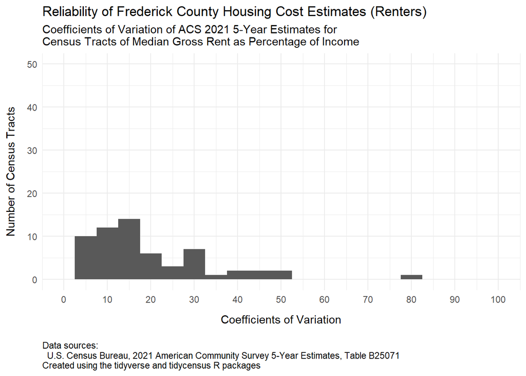

```r
mgrpi_tr %>%
  filter(!is.na(cv)) %>%
  ggplot(mapping = aes(x = cv)) +
  geom_histogram(binwidth = 5) +
  xlab("Coefficients of Variation") +
  ylab("Number of Census Tracts") +
  scale_x_continuous(limits = c(0, 100), breaks = seq(0, 100, 10)) +
  scale_y_continuous(limits = c(0, 50), breaks = seq(0, 50, 10)) +
  labs(
    title = "Reliability of Frederick County Housing Cost Estimates (Renters)",
    subtitle = paste0(
      "Coefficients of Variation of ACS 2021 5-Year Estimates for",
      "\nCensus Tracts of Median Gross Rent as Percentage of Income"
    ),
    caption = paste0(
      "Data sources:",
      "\n  U.S. Census Bureau, 2021 American Community Survey 5-Year Estimates, Table B25071",
      "\nCreated using the tidyverse and tidycensus R packages"
    )
  ) +
  theme_minimal() +
  theme(axis.title.x = element_text(margin = margin(t = 10))) +
  theme(axis.title.y = element_text(margin = margin(r = 10))) +
  theme(plot.caption = element_text(margin = margin(t = 15), hjust = 0))
```

3 of the 65 Frederick County census tracts do not have valid estimates and/or margins of error for the median gross rent as a percentage of income. Of those tracts that do have estimates, most estimates appear to be of medium or low reliability.

The following histogram shows the distribution of coefficients of variation for the tract-level estimates for homeowners with mortgages.

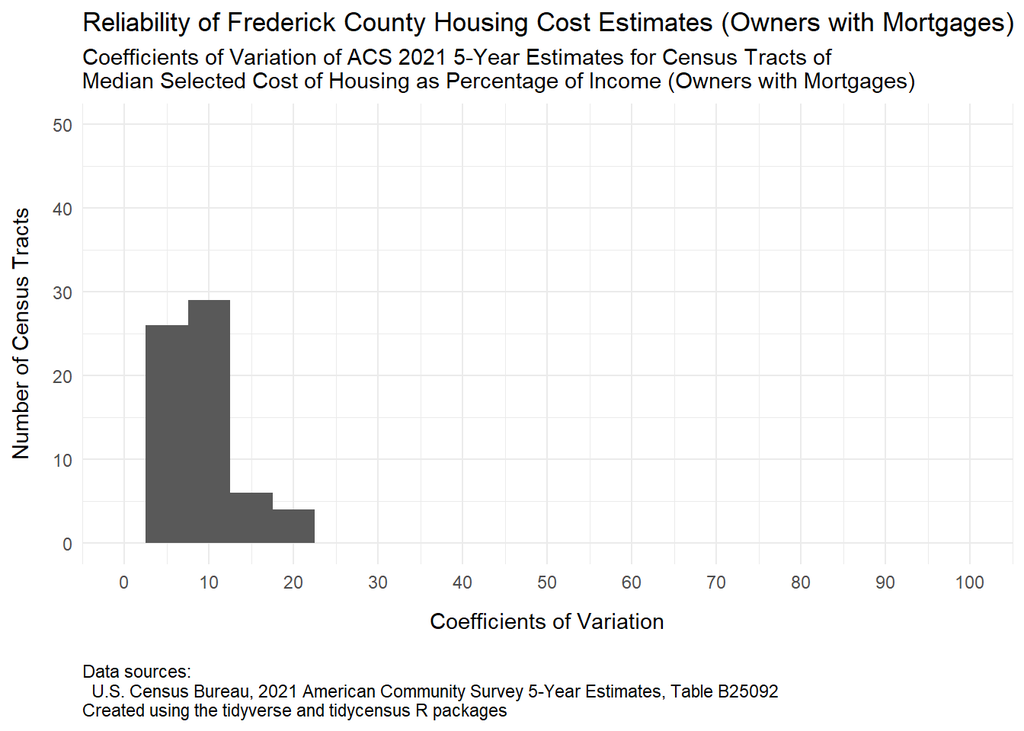

```r
mscohpi_m_tr %>%
  filter(!is.na(cv)) %>%
  ggplot(mapping = aes(x = cv)) +
  geom_histogram(binwidth = 5) +
  xlab("Coefficients of Variation") +
  ylab("Number of Census Tracts") +
  scale_x_continuous(limits = c(0, 100), breaks = seq(0, 100, 10)) +
  scale_y_continuous(limits = c(0, 50), breaks = seq(0, 50, 10)) +
  labs(
    title = "Reliability of Frederick County Housing Cost Estimates (Owners with Mortgages)",
    subtitle = paste0(
      "Coefficients of Variation of ACS 2021 5-Year Estimates for Census Tracts of",
      "\nMedian Selected Cost of Housing as Percentage of Income (Owners with Mortgages)"
    ),
    caption = paste0(
      "Data sources:",
      "\n  U.S. Census Bureau, 2021 American Community Survey 5-Year Estimates, Table B25092",
      "\nCreated using the tidyverse and tidycensus R packages"
    )
  ) +
  theme_minimal() +
  theme(axis.title.x = element_text(margin = margin(t = 10))) +
  theme(axis.title.y = element_text(margin = margin(r = 10))) +
  theme(plot.caption = element_text(margin = margin(t = 15), hjust = 0))
```

All these estimates appear to be of high or medium reliability.

Finally, the following histogram shows the distribution of coefficients of variation for the tract-level estimates for homeowners without mortgages.

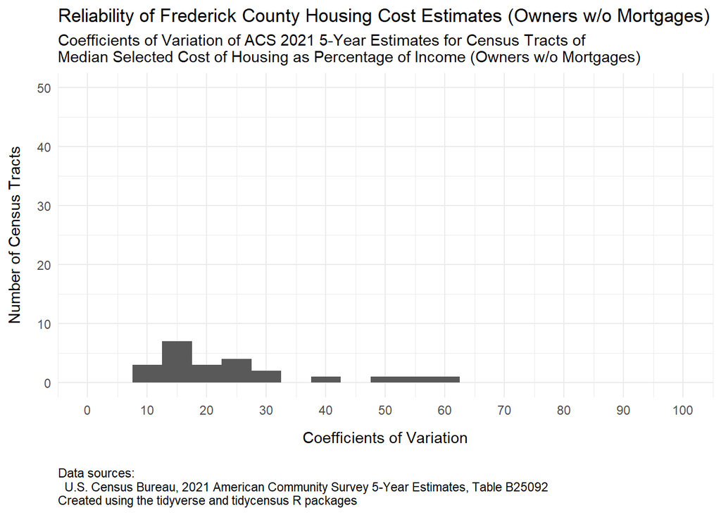

```r
mscohpi_nm_tr %>%
  filter(!is.na(cv)) %>%
  ggplot(mapping = aes(x = cv)) +
  geom_histogram(binwidth = 5) +
  xlab("Coefficients of Variation") +
  ylab("Number of Census Tracts") +
  scale_x_continuous(limits = c(0, 100), breaks = seq(0, 100, 10)) +
  scale_y_continuous(limits = c(0, 50), breaks = seq(0, 50, 10)) +
  labs(
    title = "Reliability of Frederick County Housing Cost Estimates (Owners w/o Mortgages)",
    subtitle = paste0(
      "Coefficients of Variation of ACS 2021 5-Year Estimates for Census Tracts of",
      "\nMedian Selected Cost of Housing as Percentage of Income (Owners w/o Mortgages)"
    ),
    caption = paste0(
      "Data sources:",
      "\n  U.S. Census Bureau, 2021 American Community Survey 5-Year Estimates, Table B25092",
      "\nCreated using the tidyverse and tidycensus R packages"
    )
  ) +
  theme_minimal() +
  theme(axis.title.x = element_text(margin = margin(t = 10))) +
  theme(axis.title.y = element_text(margin = margin(r = 10))) +
  theme(plot.caption = element_text(margin = margin(t = 15), hjust = 0))
```

## Frederick County housing costs by census tract

I now want to look at differing median housing costs relative to income across Frederick County. I begin by discarding estimates for any census tracts that have missing coefficients of variation, or for which the CV indicates that the estimate is of low reliability.

```r
mgrpi_tr <- mgrpi_tr %>%
  filter(!is.na(cv) & cv < 40)

mscohpi_m_tr <- mscohpi_m_tr %>%
  filter(!is.na(cv) & cv < 40)

mscohpi_nm_tr <- mscohpi_nm_tr %>%
  filter(!is.na(cv) & cv < 40)
```

The following histogram shows the distribution of median gross rents as a percentage of household income among the various census tracts in Frederick County. This histogram and the following two histograms all share the same scales on the x- and y-axis, in order to allow direct comparisons among the distributions.

```r
head(mgrpi_co)
```

```
## # A tibble: 6 × 6
##   GEOID NAME                          variable   estimate   moe    cv
##   <chr> <chr>                         <chr>         <dbl> <dbl> <dbl>
## 1 24001 Allegany County, Maryland     B25071_001     29.7   1.9  3.89
## 2 24003 Anne Arundel County, Maryland B25071_001     28.9   0.6  1.26
## 3 24005 Baltimore County, Maryland    B25071_001     31.1   0.9  1.76
## 4 24009 Calvert County, Maryland      B25071_001     28.9   3.7  7.78
## 5 24011 Caroline County, Maryland     B25071_001     32     2.6  4.94
## 6 24013 Carroll County, Maryland      B25071_001     27.9   1.9  4.14
```

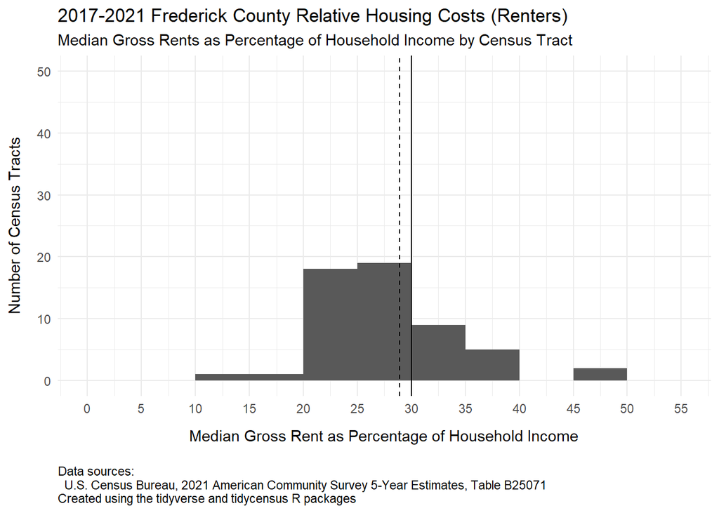

```r
mgrpi_hc <- mgrpi_co %>% filter(GEOID == "24021") %>% select(estimate) %>% as.numeric()

mgrpi_tr %>%
  ggplot(aes(x = estimate)) +
  geom_histogram(boundary = 0, binwidth = 5) +
  geom_vline(mapping = aes(xintercept = 30)) +
  geom_vline(mapping = aes(xintercept = mgrpi_hc), linetype = "dashed") +
  xlab("Median Gross Rent as Percentage of Household Income") +
  ylab("Number of Census Tracts") +
  scale_x_continuous(limits = c(0, 55), breaks = seq(0, 55, 5)) +
  scale_y_continuous(limits = c(0, 50), breaks = seq(0, 50, 10)) +
  labs(
    title = "2017-2021 Frederick County Relative Housing Costs (Renters)",
    subtitle = "Median Gross Rents as Percentage of Household Income by Census Tract",
    caption = paste0(
      "Data sources:",
      "\n  U.S. Census Bureau, 2021 American Community Survey 5-Year Estimates, Table B25071",
      "\nCreated using the tidyverse and tidycensus R packages"
    )
  ) +
  theme_minimal() +
  theme(axis.title.x = element_text(margin = margin(t = 10))) +
  theme(axis.title.y = element_text(margin = margin(r = 10))) +
  theme(plot.caption = element_text(margin = margin(t = 15), hjust = 0))
```

The solid vertical line at 30% shows the level of rent vs. income above which a household is said to be “burdened” with respect to housing costs. Note that there are many census tracts within which the median household is paying well above 30% of household income in gross rents, and is thus considered to be burdened.

The dashed line shows the estimated median gross rent as a percentage of income for all Frederick County households. Half of all households pay less than this percentage, and half more. This value is less than 30%, so less than 50% of Frederick County households overall are housing cost burdened.

The following histogram shows the distribution of median selected costs of housing as a percentage of household income for owners with mortgages among the various census tracts in Frederick County.

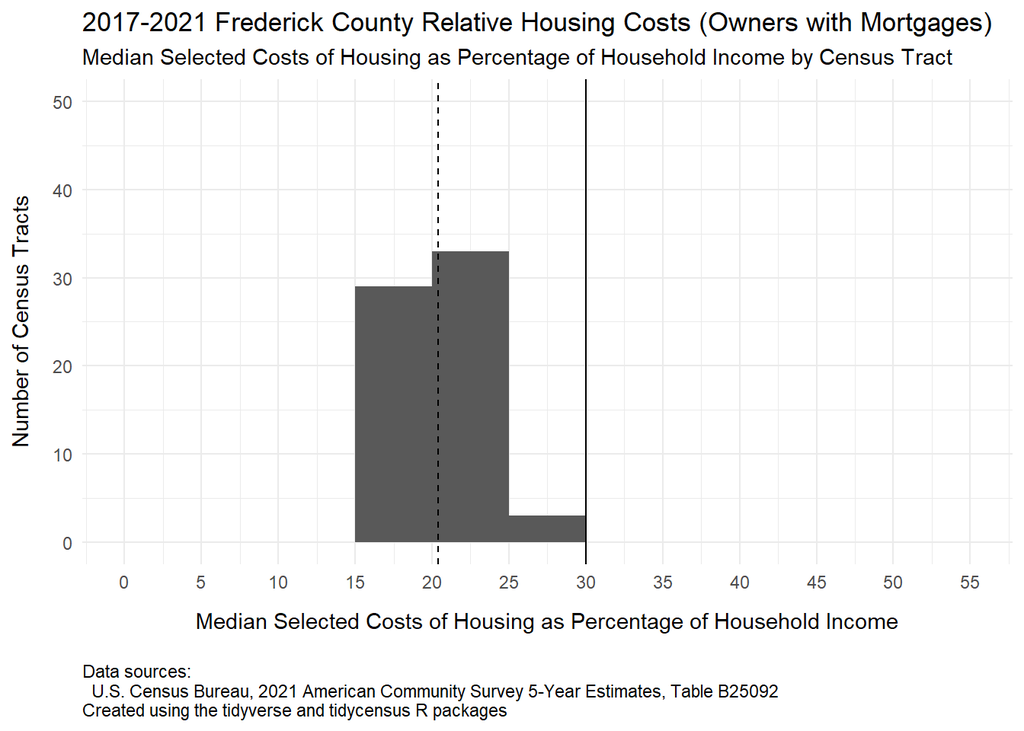

```r
mscohpi_m_hc <- mscohpi_m_co %>% filter(GEOID == "24021") %>% select(estimate) %>% as.numeric()

mscohpi_m_tr %>%
  ggplot(aes(x = estimate)) +
  geom_histogram(boundary = 0, binwidth = 5) +
  geom_vline(mapping = aes(xintercept = 30)) +
  geom_vline(mapping = aes(xintercept = mscohpi_m_hc), linetype = "dashed") +
  xlab("Median Selected Costs of Housing as Percentage of Household Income") +
  ylab("Number of Census Tracts") +
  scale_x_continuous(limits = c(0, 55), breaks = seq(0, 55, 5)) +
  scale_y_continuous(limits = c(0, 50), breaks = seq(0, 50, 10)) +
  labs(
    title = "2017-2021 Frederick County Relative Housing Costs (Owners with Mortgages)",
    subtitle = "Median Selected Costs of Housing as Percentage of Household Income by Census Tract",
    caption = paste0(
      "Data sources:",
      "\n  U.S. Census Bureau, 2021 American Community Survey 5-Year Estimates, Table B25092",
      "\nCreated using the tidyverse and tidycensus R packages"
    )
  ) +
  theme_minimal() +
  theme(axis.title.x = element_text(margin = margin(t = 10))) +
  theme(axis.title.y = element_text(margin = margin(r = 10))) +
  theme(plot.caption = element_text(margin = margin(t = 15), hjust = 0))
```

Based on this graph there no census tracts in Frederick County in which the median homeowner with a mortgage is housing cost burdened. (This of course does not rule out the possibility that some homeowners with a mortgage may be housing cost burdened. I’m referring here to the median or typical homeowner.)

The following histogram shows the distribution of median selected costs of housing as a percentage of household income for owners without mortgages among the various census tracts in Frederick County.

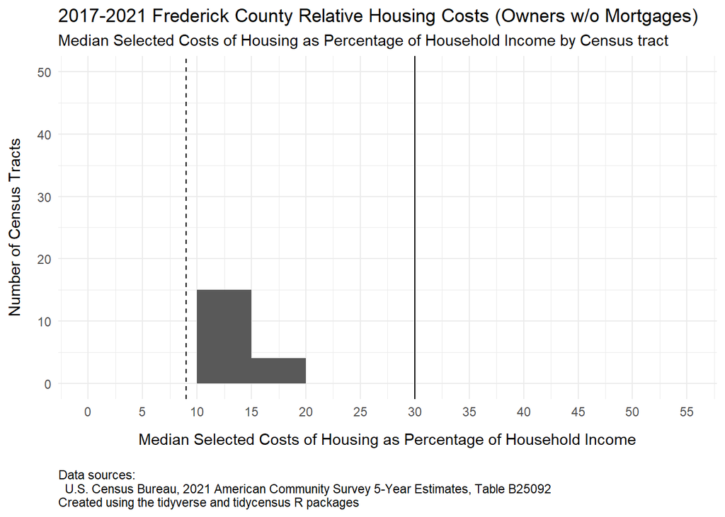

```r
mscohpi_nm_hc <- mscohpi_nm_co %>% filter(GEOID == "24021") %>% select(estimate) %>% as.numeric()

mscohpi_nm_tr %>%
  ggplot(aes(x = estimate)) +
  geom_histogram(boundary = 0, binwidth = 5) +
  geom_vline(mapping = aes(xintercept = 30)) +
  geom_vline(mapping = aes(xintercept = mscohpi_nm_hc), linetype = "dashed") +
  xlab("Median Selected Costs of Housing as Percentage of Household Income") +
  ylab("Number of Census Tracts") +
  scale_x_continuous(limits = c(0, 55), breaks = seq(0, 55, 5)) +
  scale_y_continuous(limits = c(0, 50), breaks = seq(0, 50, 10)) +
  labs(
    title = "2017-2021 Frederick County Relative Housing Costs (Owners w/o Mortgages)",
    subtitle = "Median Selected Costs of Housing as Percentage of Household Income by Census tract",
    caption = paste0(
      "Data sources:",
      "\n  U.S. Census Bureau, 2021 American Community Survey 5-Year Estimates, Table B25092",
      "\nCreated using the tidyverse and tidycensus R packages"
    )
  ) +
  theme_minimal() +
  theme(axis.title.x = element_text(margin = margin(t = 10))) +
  theme(axis.title.y = element_text(margin = margin(r = 10))) +
  theme(plot.caption = element_text(margin = margin(t = 15), hjust = 0))
```

Based on this graph, there are no census tracts of Frederick County where a median householder who does not own a mortgage is burdened with the costs of housing. Of course, this does not rule out the possibility of housing costs being a burden to some home owners who have no mortgage. I am referring to the median, or typical home owner. The median home owner household with no mortgage receives less than 15 % of their income from housing costs across nearly all census areas.

## Mapping Frederick County housing cost variation

I’m going to show the same information in a map format. First I shall determine the appropriate minimum and maximum limits for the scale to ensure that each map is uniformly sized.

```r
lower_limit <- round(min(
  min(mgrpi_tr$estimate, na.rm = TRUE),
  min(mscohpi_m_tr$estimate, na.rm = TRUE),
  min(mscohpi_nm_tr$estimate, na.rm = TRUE)
) - 4.9, -1)
```

```r
upper_limit <- round(max(
  max(mgrpi_tr$estimate, na.rm = TRUE),
  max(mscohpi_m_tr$estimate, na.rm = TRUE),
  max(mscohpi_nm_tr$estimate, na.rm = TRUE)
) + 4.9, -1)
```

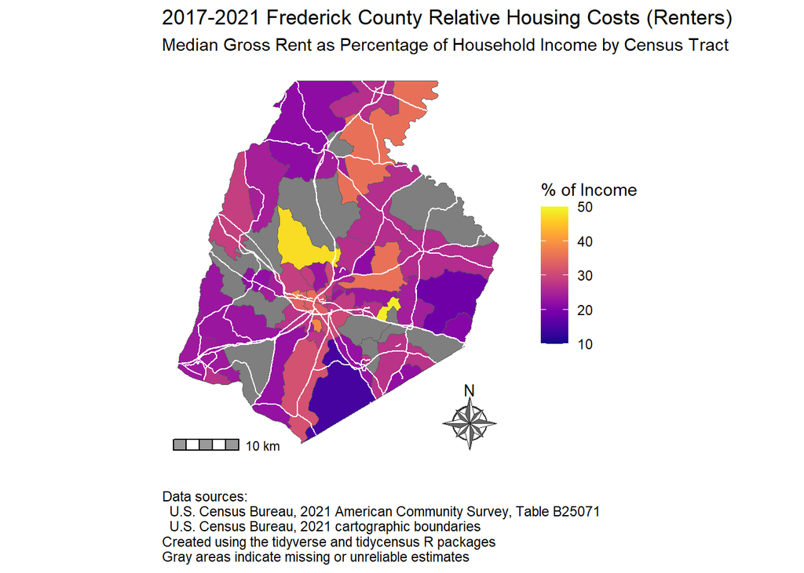

```r
# Base plot
pl1 <- mgrpi_tr %>%
  right_join(map_tr, by = "GEOID") %>%
  ggplot(aes(fill = estimate, geometry = geometry)) +
  geom_sf(size = 0) +
  geom_sf(data = major_roads_geo, color = "white", size = 1.0, fill = NA) +
  geom_sf(data = minor_roads_geo, color = "white", size = 0.5, fill = NA) +
  scale_fill_viridis(option = "plasma", name = "% of Income", limits = c(lower_limit, upper_limit), breaks = seq(lower_limit, upper_limit, 10)) +
  labs(
    title = "2017-2021 Frederick County Relative Housing Costs (Renters)",
    subtitle = "Median Gross Rent as Percentage of Household Income by Census Tract",
       caption = paste0(
         "Data sources:",
         "\n  U.S. Census Bureau, 2021 American Community Survey, Table B25071",
         "\n  U.S. Census Bureau, 2021 cartographic boundaries",
         "\nCreated using the tidyverse and tidycensus R packages",
         "\nGray areas indicate missing or unreliable estimates"
       )
  ) +
  theme(plot.caption = element_text(margin = margin(t = 15), hjust = 0)) +
  theme(axis.ticks = element_blank(), axis.text = element_blank()) +
  theme(panel.background = element_blank())

# Add scale and North arrow
pl1 +
  ggspatial::annotation_scale(
    location = "bl",
    bar_cols = c("grey60", "white"),
    text_family = "ArcherPro Book"
  ) +
  ggspatial::annotation_north_arrow(
    location = "br", which_north = "true",
    style = ggspatial::north_arrow_nautical(
      fill = c("grey40", "white"),
      line_col = "grey20",
      text_family = "ArcherPro Book"
    )
  )
```

According to the above map, several census tracts in the County are home to renters who have high costs of living. On this map and below, there are grey areas corresponding to census tracts which were not taken into account due to missing or too high coefficients of variation.

I have now compiled a comparable map of the median household housing costs for owners who take out mortgages, as a percentage of their income.

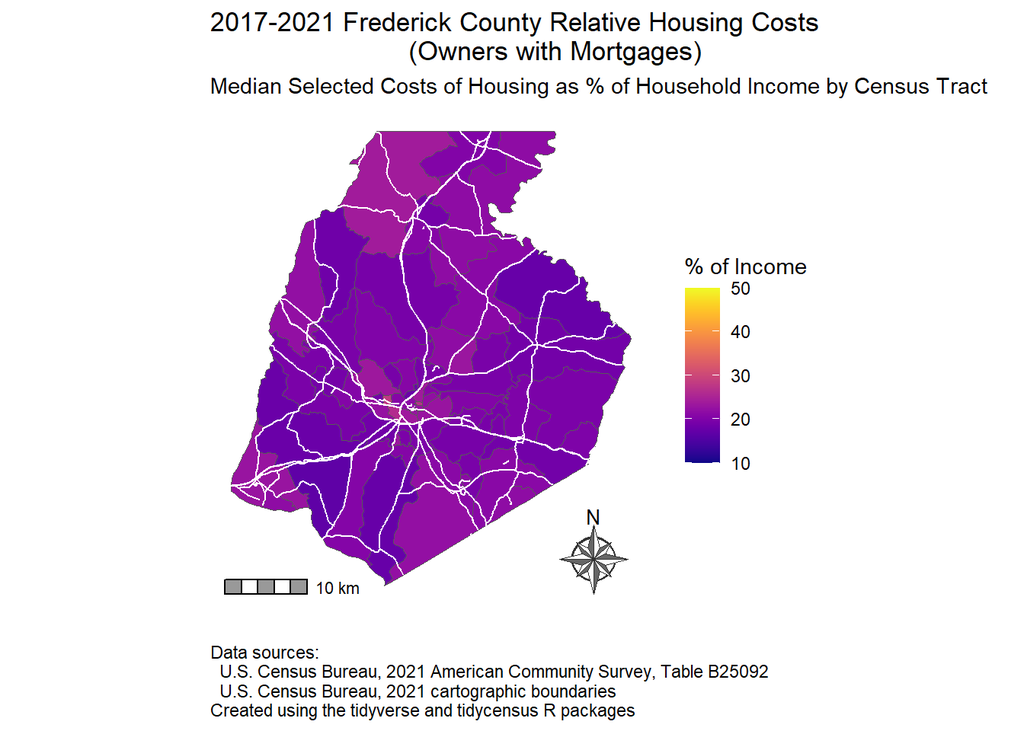

```r
# Base plot
pl2 <- mscohpi_m_tr %>%
  right_join(map_tr, by = "GEOID") %>%
  ggplot(aes(fill = estimate, geometry = geometry)) +
  geom_sf(size = 0) +
  geom_sf(data = major_roads_geo, color = "white", size = 1.0, fill = NA) +
  geom_sf(data = minor_roads_geo, color = "white", size = 0.5, fill = NA) +
  scale_fill_viridis(option = "plasma", name = "% of Income", limits = c(lower_limit, upper_limit), breaks = seq(lower_limit, upper_limit, 10)) +
  labs(
    title = paste0("2017-2021 Frederick County Relative Housing Costs ",
                  "\n                          (Owners with Mortgages)"),
    subtitle = "Median Selected Costs of Housing as % of Household Income by Census Tract",
       caption = paste0(
         "Data sources:",
         "\n  U.S. Census Bureau, 2021 American Community Survey, Table B25092",
         "\n  U.S. Census Bureau, 2021 cartographic boundaries",
         "\nCreated using the tidyverse and tidycensus R packages"
       )
  ) +
  theme(plot.caption = element_text(margin = margin(t = 15), hjust = 0)) +
  theme(axis.ticks = element_blank(), axis.text = element_blank()) +
  theme(panel.background = element_blank())

# Add scale and North arrow
pl2 +
  ggspatial::annotation_scale(
    location = "bl",
    bar_cols = c("grey60", "white"),
    text_family = "ArcherPro Book"
  ) +
  ggspatial::annotation_north_arrow(
    location = "br", which_north = "true",
    style = ggspatial::north_arrow_nautical(
      fill = c("grey40", "white"),
      line_col = "grey20",
      text_family = "ArcherPro Book"
    )
  )
```

This graph shows the corresponding histogram in nearly all of Frederick County’s census tracts that aren’t housing cost burdened with a mortgage, above the median home-owning household.

Finally, for owners who do not hold a mortgage, I draw up an equivalent map of the median selected cost of housing as percentage of household income.

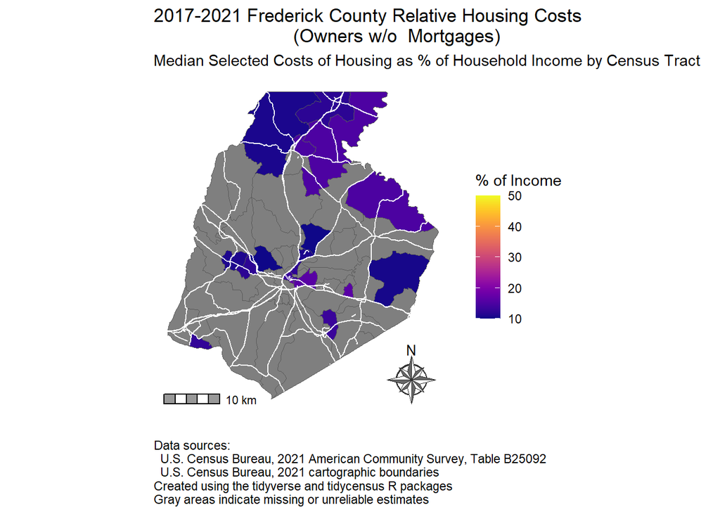

```r
# Base plot
pl3 <- mscohpi_nm_tr %>%
  filter(!is.na(cv)) %>%
  filter(cv < 40) %>%
  right_join(map_tr, by = "GEOID") %>%
 ggplot(aes(fill = estimate, geometry = geometry)) +
  geom_sf(size = 0) +
  geom_sf(data = major_roads_geo, color = "white", size = 1.0, fill = NA) +
  geom_sf(data = minor_roads_geo, color = "white", size = 0.5, fill = NA) +
  scale_fill_viridis(option = "plasma", name = "% of Income", limits = c(lower_limit, upper_limit), breaks = seq(lower_limit, upper_limit, 10)) +
  labs(
    #title = "2017-2021 Frederick County Relative Housing Costs (Owners w/o Mortgages)",
    title = paste0("2017-2021 Frederick County Relative Housing Costs ",
                  "\n                          (Owners w/o  Mortgages)"),
    subtitle = "Median Selected Costs of Housing as % of Household Income by Census Tract",
       caption = paste0(
         "Data sources:",
         "\n  U.S. Census Bureau, 2021 American Community Survey, Table B25092",
         "\n  U.S. Census Bureau, 2021 cartographic boundaries",
         "\nCreated using the tidyverse and tidycensus R packages",
         "\nGray areas indicate missing or unreliable estimates"
       )
  ) +
  theme(plot.caption = element_text(margin = margin(t = 15), hjust = 0)) +
  theme(axis.ticks = element_blank(), axis.text = element_blank()) +
  theme(panel.background = element_blank())

# Add scale and North arrow
pl3 +
  ggspatial::annotation_scale(
    location = "bl",
    bar_cols = c("grey60", "white"),
    text_family = "ArcherPro Book"
  ) +
  ggspatial::annotation_north_arrow(
    location = "br", which_north = "true",
    style = ggspatial::north_arrow_nautical(
      fill = c("grey40", "white"),
      line_col = "grey20",
      text_family = "ArcherPro Book"
    )
  )
```

```r
#library(sf)
st_write(mgrpi_tr, "../bin/mgrpi_tr_Variables.geoJSON")
```

```
## Writing layer `mgrpi_tr_Variables' to data source
##   `../bin/mgrpi_tr_Variables.geoJSON' using driver `GeoJSON'
## Writing 55 features with 6 fields without geometries.
```

```r
st_write(mscohpi_m_tr, "../bin/mscohpi_m_tr_Variables.geoJSON")
```

```
## Writing layer `mscohpi_m_tr_Variables' to data source
##   `../bin/mscohpi_m_tr_Variables.geoJSON' using driver `GeoJSON'
## Writing 65 features with 6 fields without geometries.
```

```r
st_write(mscohpi_nm_tr, "../bin/mscohpi_nm_tr_Variables.geoJSON")
```

```
## Writing layer `mscohpi_nm_tr_Variables' to data source
##   `../bin/mscohpi_nm_tr_Variables.geoJSON' using driver `GeoJSON'
## Writing 19 features with 6 fields without geometries.
```